# Day Care Fines

## Caleb’s Analysis

```r
library(mosaic)
library(DT)
library(pander)
library(car)
library(tidyverse)
library(plotly)

late <- read.csv("~/Documents/M325_Git/Data/late.csv", header=TRUE)
```

### Study Details

This background is quoted directly from the article [“A Fine is a Price”](http://rady.ucsd.edu/faculty/directory/gneezy/pub/docs/fine.pdf).

There are two types of day-care centers in Israel: private and public. A study was conducted in 10 private day-care centers in the city of Haifa from January to June 1998. All of these centers are located in the same part of town, and there is no important difference among them. During the day children are organized into groups according to age, from 1 to 4 years old. Each day-care center is allowed to hold a maximum of 35 children. In some exceptional cases a few additional children are allowed. The fee for each child is NIS 1,400 per month. (The NIS is the New Israeli Shekel.) At the time of the study, a U.S. dollar was worth approximately NIS 3.68, so the fee was about $380 at that time.

The contract signed at the beginning of the year states that the day-care center operates between 0730 and 1600. There is no mention of what happens if parents come late to pick up their children. In particular, before the beginning of the study, there was no fine for coming late. When parents did not come on time, one of the teachers had to wait with the children concerned. Teachers would rotate in this task, which is considered part of the job of a teacher, a fact that is clearly explained when a teacher is hired. Parents rarely came after 1630.

A natural option [to fix the problem of parents showing up late] is to introduce a fine: every time a parent comes late, [they] will have to pay a fine. Will that reduce the number of parents who come late? If the fine is removed, will things revert back to the way they were originally?

The overall period of the study was 20 weeks. In the first 4 weeks we simply recorded the number of parents who arrived late each week. At the beginning of the fifth week, we introduced a fine in six of the 10 day-care centers, which had been selected randomly. The announcement of the fine was made with a note posted on the bulletin board of the day-care center. Parents tend to look at this board every day, since important announcements are posted there. The announcement specified that the fine would be NIS 10 for a delay of 10 minutes or more. The fine was per child; thus, if parents had two children in the center and they came late, they had to pay NIS 20. Payment was made to the principal of the day-care center at the end of the month. Since monthly payments are made to the owner during the year, the fines were added to those amounts. The money was paid to the owner, rather then to the teacher who was staying late (and did not get any additional money). The teachers were informed of the fine but not of the study. Registering the names of parents who came late was a common practice in any case.

At the beginning of the seventeenth week, the fine was removed with no explanation. Notice of the cancellation was posted on the board. If parents asked why the fines were removed, the principals were instructed to reply that the fine had been a trial for a limited time and that the results of this trial were now being evaluated.

A comparison with other fines in Israel may give an idea of the size of the penalty that was introduced. A fine of NIS 10 is relatively small but not insignificant. In comparison, the fine for illegal parking is NIS 75; the fine for driving through a red light is NIS 1,000 plus penalties; the fine for not collecting the droppings of a dog is NIS 360. For many of these violations, however, detection and enforcement are low or, as in the case of dog dirt, nonexistent in practice. A baby-sitter earns between NIS 15 and NIS 20 per hour. The average gross salary per month in Israel at the time of the study was NIS 5,595.

### The Data (Wide)

The `late` Day Care Center data is shown here in the “wide data format”.

```r
pander(late, split.tables = Inf)
```

| Treatment | Center | No.ofChidren | Week1 | Week2 | Week3 | Week4 | Week5 | Week6 | Week7 | Week8 | Week9 | Week10 | Week11 | Week12 | Week13 | Week14 | Week15 | Week16 | Week17 | Week18 | Week19 | Week20 |
| --- | --- | --- | --- | --- | --- | --- | --- | --- | --- | --- | --- | --- | --- | --- | --- | --- | --- | --- | --- | --- | --- | --- |
| Fine | 1 | 37 | 8 | 8 | 7 | 6 | 8 | 9 | 9 | 12 | 13 | 13 | 15 | 13 | 14 | 16 | 14 | 15 | 16 | 13 | 15 | 17 |
| Fine | 2 | 35 | 6 | 7 | 3 | 5 | 2 | 11 | 14 | 9 | 16 | 12 | 10 | 14 | 14 | 16 | 12 | 17 | 14 | 10 | 14 | 15 |
| Fine | 3 | 35 | 8 | 9 | 8 | 9 | 3 | 5 | 15 | 18 | 16 | 14 | 20 | 18 | 25 | 22 | 27 | 19 | 20 | 23 | 23 | 22 |
| Fine | 4 | 34 | 10 | 3 | 14 | 9 | 6 | 24 | 8 | 22 | 22 | 19 | 25 | 18 | 23 | 22 | 24 | 17 | 15 | 23 | 25 | 18 |
| Fine | 5 | 33 | 13 | 12 | 9 | 13 | 15 | 10 | 27 | 28 | 35 | 10 | 24 | 32 | 29 | 29 | 26 | 31 | 26 | 35 | 29 | 28 |
| Fine | 6 | 28 | 5 | 8 | 7 | 5 | 5 | 9 | 12 | 14 | 19 | 17 | 14 | 13 | 10 | 15 | 14 | 16 | 6 | 12 | 17 | 13 |
| Control | 7 | 35 | 7 | 10 | 12 | 6 | 4 | 13 | 7 | 8 | 5 | 12 | 3 | 5 | 6 | 13 | 7 | 4 | 7 | 10 | 4 | 6 |
| Control | 8 | 34 | 12 | 9 | 14 | 18 | 10 | 11 | 6 | 15 | 14 | 13 | 7 | 12 | 9 | 9 | 17 | 8 | 5 | 11 | 8 | 13 |
| Control | 9 | 34 | 3 | 4 | 9 | 3 | 3 | 5 | 9 | 5 | 2 | 7 | 6 | 6 | 9 | 4 | 9 | 2 | 3 | 8 | 3 | 5 |
| Control | 10 | 32 | 15 | 13 | 13 | 12 | 10 | 9 | 15 | 15 | 15 | 10 | 17 | 12 | 13 | 11 | 14 | 17 | 12 | 9 | 15 | 13 |

### The Data (Long)

The `Late` Day Care Center data is shown here in the “long data format”.

```r
Late <- reshape(late,
                varying = paste("Week",1:20, sep=""),
                v.names = "No.ofLateChildren",
                timevar = "Week",
                times = 1:20,
                idvar = "Center",
                new.row.names = 1:200,
                direction = "long")
pander(Late)
```

| Treatment | Center | No.ofChidren | Week | No.ofLateChildren |
| --- | --- | --- | --- | --- |
| Fine | 1 | 37 | 1 | 8 |
| Fine | 2 | 35 | 1 | 6 |
| Fine | 3 | 35 | 1 | 8 |
| Fine | 4 | 34 | 1 | 10 |
| Fine | 5 | 33 | 1 | 13 |
| Fine | 6 | 28 | 1 | 5 |
| Control | 7 | 35 | 1 | 7 |
| Control | 8 | 34 | 1 | 12 |
| Control | 9 | 34 | 1 | 3 |
| Control | 10 | 32 | 1 | 15 |
| Fine | 1 | 37 | 2 | 8 |
| Fine | 2 | 35 | 2 | 7 |
| Fine | 3 | 35 | 2 | 9 |
| Fine | 4 | 34 | 2 | 3 |
| Fine | 5 | 33 | 2 | 12 |
| Fine | 6 | 28 | 2 | 8 |
| Control | 7 | 35 | 2 | 10 |
| Control | 8 | 34 | 2 | 9 |
| Control | 9 | 34 | 2 | 4 |
| Control | 10 | 32 | 2 | 13 |
| Fine | 1 | 37 | 3 | 7 |
| Fine | 2 | 35 | 3 | 3 |
| Fine | 3 | 35 | 3 | 8 |
| Fine | 4 | 34 | 3 | 14 |
| Fine | 5 | 33 | 3 | 9 |
| Fine | 6 | 28 | 3 | 7 |
| Control | 7 | 35 | 3 | 12 |
| Control | 8 | 34 | 3 | 14 |
| Control | 9 | 34 | 3 | 9 |
| Control | 10 | 32 | 3 | 13 |

[output cut: 170 more lines]

### Overview

My analysis will evaluate the results of a 20 week study on parents picking their children up late from day care centers in the city Haifa. This study is explained in detail in the Study Details tab so I will not elaborate here.

As the duration of the study is broken up into three periods (Initial Period, Fining Period, and Post-Fining Period), I will analyze the data by period rather than by week. Further, since each day-care center has a different number of children I chose to investigate the proportion of children picked up late rather than the number of children.

I will use an ANOVA test to evaluate the impact of the treatment used in each period on the proportion of children picked up late. This ANOVA will us a significance level of .05. My null hypothesis that treatment and testing period will have no impact on the proportion of children picked up late with my alt hypothesis being that at least one of the factors will make a difference on the proportion of children picked up late.

```r
Late$Period <- cut(Late$Week, c(0,4,16,Inf), labels = c("Pre-Fine","Fine","Post-Fine"))

Late$Proportion<- round(Late$No.ofLateChildren/Late$No.ofChidren,2)
```

Presented here is my ANOVA using the constraints mentioned in the Overview:

```r
Late.aov<- aov(data=Late,Proportion~Treatment+ Period +Treatment:Period)
pander(summary(Late.aov))
```

Analysis of Variance Model

|  | Df | Sum Sq | Mean Sq | F value | Pr(>F) |
| --- | --- | --- | --- | --- | --- |
| **Treatment** | 1 | 1.555 | 1.555 | 52.3 | 1.073e-11 |
| **Period** | 2 | 0.743 | 0.3715 | 12.49 | 7.876e-06 |
| **Treatment:Period** | 2 | 0.7521 | 0.376 | 12.65 | 6.878e-06 |
| **Residuals** | 194 | 5.769 | 0.02973 | NA | NA |

While this ANOVA test does give reason to reject the null hypothesis, it is still hard to visualize the impact this experiment had on the number of children who were picked up late. To assist in allowing the reader to see the large impact made, I have included the xyplot below. The trendlines show that averages of how many children were picked up late in each period for each treatment group.

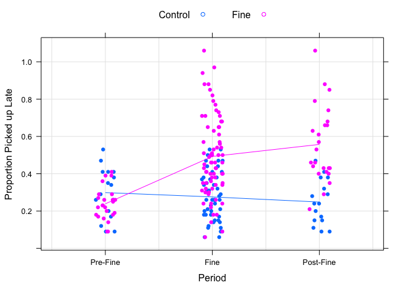

```r
xyplot( Proportion ~ Period, data=  Late, groups = Treatment,
        main="", type=c("p","a"), jitter.x=TRUE, pch=16,
        auto.key=list(columns = nlevels(Late$Treatment)),
        grid=T, ylab = "Proportion Picked up Late")
```

A different view of this data uses Week instead of Period. This plot is more overwhelming, but shows an interesting view of the impact of the period of the study where the late fee was initiated.

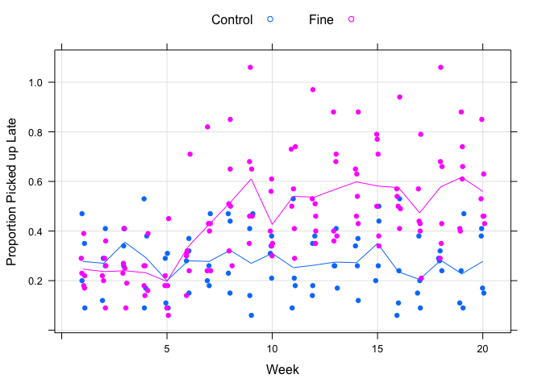

```r
xyplot( Proportion ~ Week, data=  Late, groups = Treatment,
        main="", type=c("p","a"), jitter.x=TRUE, pch=16,
        auto.key=list(columns = nlevels(Late$Treatment)),
        grid=T, ylab = "Proportion Picked up Late")
```

Assuming children spend 20 days a month at a day care center then their parents will spend NIS 70 each day on childcare per child. 10 additional NIS is a very small cost to stay late at work to finish a project, finish something at home, or to do any other thing when you normally should be picking your child up from day care. The institution of a late fee may have eliviated guilt and urgency to get your child right away, now parents were just paying for the service of more time for thier child at day care.